# Growth Curve Report #1

Date: 2016-06-29

This report contains a searchable table, followed by publication-ready tables.

# Summary

### Notes

1. All available models are contained in the dynamic table, while only the ‘aehplus’ models are shown in the static tables.

### Unanswered Questions

1. How should we handle entries that are entirely missing?
2. How should we handle entries containing null/NA results?

# Dynamic Table -Long (and filtered)

This table has a few filters on it already, so it won’t clog your computer with 117,600 rows. It’s only `model_type=="aehplus" & subgroup=="female" & process_a=="gait"`.

|  | study_name | process_b | subject_count | value | process | coefficient | stat |
| --- | --- | --- | --- | --- | --- | --- | --- |
| 1 | eas | trailsb | 150 | 110.036 | a | 00 | est |
| 2 | eas | categories | 150 | 110.596 | a | 00 | est |
| 3 | eas | fas | 150 | 109.603 | a | 00 | est |
| 4 | eas | information | 130 | 109.787 | a | 00 | est |
| 5 | eas | waisvocab | 150 | 109.774 | a | 00 | est |
| 6 | eas | bnt | 150 | 111.421 | a | 00 | est |
| 7 | eas | digit_tot | 150 | 109.876 | a | 00 | est |
| 8 | eas | logic_tot | 150 | 110.347 | a | 00 | est |
| 9 | eas | mmms | 72 | 105.724 | a | 00 | est |
| 10 | eas | block | 150 | 110.351 | a | 00 | est |

[output cut: 3126 more lines]

# Dynamic Table -Long (and collapsed and filtered)

# Dynamic Table -Wide

Intercept and slope have been condensed (so each cell has ‘est’, ‘se’, and ‘pval’) and placed side-by-side.

|  | study name | process | subgroup | model type | n | species | intercept | slope |
| --- | --- | --- | --- | --- | --- | --- | --- | --- |
| 1 | eas | block | female | a | 563 | intercept | 20.62(0.81),p&lt;.01 | 0.67(0.18),p&lt;.01 |
| 2 | eas | block | female | a | 563 | age | -0.18(0.09),p=.03 | -0.03(0.02),p=.12 |
| 3 | eas | block | female | a | 563 | education | --,p= ---- | --,p= ---- |
| 4 | eas | block | female | a | 563 | height | --,p= ---- | --,p= ---- |
| 5 | eas | block | female | a | 563 | smoking | --,p= ---- | --,p= ---- |
| 6 | eas | block | female | a | 563 | cardio | --,p= ---- | --,p= ---- |
| 7 | eas | block | female | a | 563 | diabetes | --,p= ---- | --,p= ---- |
| 8 | eas | block | female | ae | 563 | intercept | 13.93(1.11),p&lt;.01 | 1.12(0.26),p&lt;.01 |
| 9 | eas | block | female | ae | 563 | age | -0.16(0.08),p=.04 | -0.03(0.02),p=.11 |
| 10 | eas | block | female | ae | 563 | education | 1.06(0.12),p&lt;.01 | -0.08(0.03),p&lt;.01 |

[output cut: 4344 more lines]

# Static Tables

The ‘aehplus’ model (with covariates *a*ge, *e*ducation, *h*ealth, and others) is shown for each combination of

- study,
- process, and
- gender.

## eas

| Process | Gender | $n$ | species | intercept | slope |
| --- | --- | --- | --- | --- | --- |
| block | female | 150 | intercept | 18.93(2.41),$p$<.01 | 0.80(0.47),$p$=.09 |
|  |  |  | age | -0.15(0.16),$p$=.37 | -0.04(0.03),$p$=.15 |
|  |  |  | education | 0.88(0.26),$p$<.01 | -0.07(0.05),$p$=.17 |
|  |  |  | height | -0.01(0.11),$p$=.91 | -0.01(0.02),$p$=.66 |
|  |  |  | smoking | 1.53(1.44),$p$=.29 | -0.10(0.26),$p$=.69 |
|  |  |  | cardio | -0.38(2.44),$p$=.88 | -0.07(0.73),$p$=.93 |
|  |  |  | diabetes | -4.39(2.59),$p$=.09 | 0.18(0.40),$p$=.65 |
| block | male | 72 | intercept | 24.09(7.14),$p$<.01 | 1.46(1.58),$p$=.36 |
|  |  |  | age | 0.25(0.45),$p$=.57 | -0.09(0.08),$p$=.28 |
|  |  |  | education | 0.58(0.53),$p$=.28 | -0.09(0.11),$p$=.44 |
|  |  |  | height | 0.04(0.22),$p$=.85 | -0.03(0.05),$p$=.48 |
|  |  |  | smoking | -3.94(3.47),$p$=.26 | 0.25(0.78),$p$=.80 |
|  |  |  | cardio | 0.32(4.47),$p$=.93 | 0.22(1.57),$p$=.89 |
|  |  |  | diabetes | -3.76(3.99),$p$=.35 | -0.42(1.11),$p$=.71 |
| bnt | female | 150 | intercept | 10.80(0.66),$p$<.01 | -0.06(0.16),$p$=.69 |
|  |  |  | age | -0.06(0.05),$p$=.29 | -0.01(0.01),$p$=.52 |
|  |  |  | education | 0.27(0.07),$p$<.01 | -0.00(0.02),$p$=.90 |
|  |  |  | height | 0.00(0.03),$p$=.88 | 0.00(0.01),$p$=.97 |
|  |  |  | smoking | 0.45(0.24),$p$=.07 | 0.01(0.11),$p$=.91 |
|  |  |  | cardio | -0.82(0.50),$p$=.11 | 0.20(0.19),$p$=.27 |
|  |  |  | diabetes | -1.64(0.48),$p$<.01 | -0.03(0.12),$p$=.79 |
| bnt | male | 72 | intercept | 11.09(1.92),$p$<.01 | 0.19(0.43),$p$=.64 |
|  |  |  | age | 0.04(0.08),$p$=.64 | -0.03(0.02),$p$=.28 |
|  |  |  | education | 0.10(0.16),$p$=.54 | -0.00(0.03),$p$=.88 |
|  |  |  | height | 0.01(0.07),$p$=.87 | 0.00(0.02),$p$=.89 |
|  |  |  | smoking | 0.91(0.94),$p$=.34 | -0.20(0.24),$p$=.39 |
|  |  |  | cardio | -0.22(1.17),$p$=.83 | -0.02(0.61),$p$=.97 |
|  |  |  | diabetes | -0.37(1.00),$p$=.70 | 0.22(0.28),$p$=.44 |
| categories | female | 150 | intercept | 38.58(2.78),$p$<.01 | -0.78(0.72),$p$=.28 |
|  |  |  | age | -0.35(0.19),$p$=.07 | -0.03(0.04),$p$=.48 |

[output cut: 166 more lines]

## elsa

| Process | Gender | $n$ | species | intercept | slope |
| --- | --- | --- | --- | --- | --- |
| fev | female | 3,511 | intercept | 1.88(0.02),$p$<.01 | -0.02(0.00),$p$<.01 |
|  |  |  | age | –,$p$= —- | –,$p$= —- |
|  |  |  | education | 0.10(0.02),$p$<.01 | 0.00(0.00),$p$=.65 |
|  |  |  | height | 0.03(0.00),$p$<.01 | 0.00(0.00),$p$=.03 |
|  |  |  | smoking | -0.11(0.02),$p$<.01 | -0.00(0.00),$p$=.46 |
|  |  |  | cardio | -0.11(0.03),$p$<.01 | 0.00(0.00),$p$=.50 |
|  |  |  | diabetes | -0.05(0.04),$p$=.18 | -0.00(0.01),$p$=.53 |
| fev | male | 3,091 | intercept | 2.63(0.03),$p$<.01 | -0.02(0.00),$p$<.01 |
|  |  |  | age | –,$p$= —- | –,$p$= —- |
|  |  |  | education | 0.20(0.03),$p$<.01 | -0.01(0.00),$p$=.08 |
|  |  |  | height | 0.03(0.00),$p$<.01 | 0.00(0.00),$p$=.93 |
|  |  |  | smoking | -0.21(0.03),$p$<.01 | 0.00(0.00),$p$=.35 |
|  |  |  | cardio | -0.20(0.04),$p$<.01 | 0.00(0.00),$p$=.57 |
|  |  |  | diabetes | -0.06(0.05),$p$=.18 | -0.02(0.01),$p$=.01 |
| fev100 | female | 3,511 | intercept | 188.50(1.68),$p$<.01 | -2.13(0.19),$p$<.01 |
|  |  |  | age | –,$p$= —- | –,$p$= —- |
|  |  |  | education | 10.17(1.79),$p$<.01 | 0.09(0.21),$p$=.65 |
|  |  |  | height | 2.76(0.15),$p$<.01 | -0.04(0.02),$p$=.03 |
|  |  |  | smoking | -10.89(1.70),$p$<.01 | -0.15(0.20),$p$=.46 |
|  |  |  | cardio | -11.18(3.09),$p$<.01 | 0.31(0.46),$p$=.50 |
|  |  |  | diabetes | -5.14(3.83),$p$=.18 | -0.35(0.56),$p$=.53 |
| fev100 | male | 3,091 | intercept | 262.62(3.21),$p$<.01 | -2.21(0.44),$p$<.01 |
|  |  |  | age | –,$p$= —- | –,$p$= —- |
|  |  |  | education | 20.33(2.89),$p$<.01 | -0.64(0.36),$p$=.08 |
|  |  |  | height | 3.34(0.21),$p$<.01 | -0.00(0.02),$p$=.93 |
|  |  |  | smoking | -21.05(2.83),$p$<.01 | 0.32(0.34),$p$=.35 |
|  |  |  | cardio | -19.51(3.86),$p$<.01 | 0.28(0.49),$p$=.57 |
|  |  |  | diabetes | -6.20(4.67),$p$=.18 | -1.60(0.63),$p$=.01 |
| fluency | female | 3,510 | intercept | 17.64(0.18),$p$<.01 | -0.08(0.03),$p$<.01 |
|  |  |  | age | –,$p$= —- | –,$p$= —- |

[output cut: 68 more lines]

## hrs

| Process | Gender | $n$ | species | intercept | slope |
| --- | --- | --- | --- | --- | --- |
| gait | female | 370 | intercept | 0.79(0.02),$p$<.01 | -0.03(0.00),$p$<.01 |
|  |  |  | age | -0.01(0.00),$p$<.01 | -0.00(0.00),$p$<.01 |
|  |  |  | education | 0.01(0.00),$p$<.01 | 0.00(0.00),$p$=.06 |
|  |  |  | height | 0.16(0.19),$p$=.38 | -0.04(0.04),$p$=.39 |
|  |  |  | smoking | -0.04(0.04),$p$=.29 | 0.00(0.01),$p$=.75 |
|  |  |  | cardio | -0.03(0.02),$p$=.16 | 0.00(0.00),$p$=.89 |
|  |  |  | diabetes | -0.06(0.03),$p$=.02 | 0.00(0.01),$p$=.99 |
| gait | male | 318 | intercept | 0.86(0.04),$p$<.01 | -0.02(0.01),$p$=.02 |
|  |  |  | age | -0.01(0.00),$p$<.01 | -0.00(0.00),$p$=.11 |
|  |  |  | education | 0.01(0.00),$p$=.03 | 0.00(0.00),$p$=.15 |
|  |  |  | height | 0.12(0.15),$p$=.45 | -0.02(0.05),$p$=.72 |
|  |  |  | smoking | -0.06(0.05),$p$=.18 | 0.02(0.01),$p$=.04 |
|  |  |  | cardio | -0.01(0.02),$p$=.55 | -0.00(0.01),$p$=.63 |
|  |  |  | diabetes | -0.07(0.03),$p$=.02 | -0.01(0.01),$p$=.22 |
| grip | female | 641 | intercept | 23.63(0.89),$p$<.01 | -0.25(0.19),$p$=.19 |
|  |  |  | age | -0.29(0.07),$p$<.01 | 0.00(0.01),$p$=.95 |
|  |  |  | education | 0.22(0.18),$p$=.23 | -0.05(0.04),$p$=.17 |
|  |  |  | height | 9.90(6.14),$p$=.11 | 1.83(1.28),$p$=.15 |
|  |  |  | smoking | -1.99(1.07),$p$=.06 | 0.11(0.22),$p$=.62 |
|  |  |  | cardio | -1.77(0.74),$p$=.02 | -0.03(0.16),$p$=.87 |
|  |  |  | diabetes | -1.13(0.70),$p$=.10 | 0.03(0.15),$p$=.83 |
| grip | male | 507 | intercept | 35.24(1.12),$p$<.01 | -0.56(0.23),$p$=.02 |
|  |  |  | age | -0.51(0.05),$p$<.01 | -0.01(0.01),$p$=.20 |
|  |  |  | education | 0.01(0.14),$p$=.95 | -0.02(0.03),$p$=.55 |
|  |  |  | height | 25.64(4.96),$p$<.01 | -0.77(1.01),$p$=.45 |
|  |  |  | smoking | 1.06(2.86),$p$=.71 | -0.58(0.54),$p$=.27 |
|  |  |  | cardio | 0.23(0.89),$p$=.80 | -0.04(0.17),$p$=.80 |
|  |  |  | diabetes | -2.04(0.80),$p$=.01 | -0.20(0.19),$p$=.29 |
| pef | female | 715 | intercept | 256.75(6.16),$p$<.01 | -2.13(1.28),$p$=.10 |
|  |  |  | age | -3.83(0.24),$p$<.01 | -0.26(0.04),$p$<.01 |

[output cut: 68 more lines]

## ilse

| Process | Gender | $n$ | species | intercept | slope |
| --- | --- | --- | --- | --- | --- |
| block | female | 225 | intercept | 19.53(4.80),$p$<.01 | -0.17(0.44),$p$=.70 |
|  |  |  | age | -0.64(0.67),$p$=.34 | 0.02(0.06),$p$=.73 |
|  |  |  | education | 5.61(1.15),$p$<.01 | -0.03(0.10),$p$=.78 |
|  |  |  | height | -0.01(0.10),$p$=.95 | 0.00(0.01),$p$=.89 |
|  |  |  | smoking | -2.39(1.18),$p$=.04 | -0.02(0.10),$p$=.82 |
|  |  |  | cardio | 1.01(1.24),$p$=.41 | 0.11(0.11),$p$=.35 |
|  |  |  | diabetes | –,$p$= —- | –,$p$= —- |
| block | male | 252 | intercept | 22.73(3.92),$p$<.01 | -0.75(0.45),$p$=.10 |
|  |  |  | age | -0.43(0.54),$p$=.43 | -0.06(0.06),$p$=.29 |
|  |  |  | education | 6.06(1.15),$p$<.01 | -0.20(0.11),$p$=.07 |
|  |  |  | height | 0.15(0.08),$p$=.06 | 0.00(0.01),$p$=.96 |
|  |  |  | smoking | -1.28(1.16),$p$=.27 | 0.04(0.12),$p$=.76 |
|  |  |  | cardio | -0.54(1.11),$p$=.62 | -0.17(0.11),$p$=.12 |
|  |  |  | diabetes | –,$p$= —- | –,$p$= —- |
| fluency | female | 225 | intercept | 24.11(5.27),$p$<.01 | -0.18(0.51),$p$=.73 |
|  |  |  | age | -0.68(0.73),$p$=.35 | -0.01(0.07),$p$=.92 |
|  |  |  | education | 6.29(1.29),$p$<.01 | 0.12(0.12),$p$=.32 |
|  |  |  | height | -0.04(0.11),$p$=.74 | 0.01(0.01),$p$=.38 |
|  |  |  | smoking | 0.15(1.25),$p$=.91 | 0.01(0.12),$p$=.95 |
|  |  |  | cardio | -0.96(1.42),$p$=.50 | -0.01(0.14),$p$=.96 |
|  |  |  | diabetes | –,$p$= —- | –,$p$= —- |
| fluency | male | 252 | intercept | 23.80(4.66),$p$<.01 | -0.08(0.46),$p$=.87 |
|  |  |  | age | -0.32(0.66),$p$=.62 | 0.01(0.06),$p$=.89 |
|  |  |  | education | 5.43(1.20),$p$<.01 | 0.00(0.12),$p$=.98 |
|  |  |  | height | 0.15(0.09),$p$=.10 | -0.01(0.01),$p$=.37 |
|  |  |  | smoking | -0.52(1.29),$p$=.68 | -0.04(0.12),$p$=.73 |
|  |  |  | cardio | 0.51(1.24),$p$=.68 | 0.11(0.13),$p$=.43 |
|  |  |  | diabetes | –,$p$= —- | –,$p$= —- |
| grip | female | 225 | intercept | 87.69(13.71),$p$<.01 | -6.66(2.28),$p$<.01 |
|  |  |  | age | 2.80(1.85),$p$=.13 | -0.58(0.31),$p$=.06 |

[output cut: 68 more lines]

## lasa

| Process | Gender | $n$ | species | intercept | slope |
| --- | --- | --- | --- | --- | --- |
| gait | female | 782 | intercept | 7.77(0.17),$p$<.01 | 0.42(0.05),$p$<.01 |
|  |  |  | age | 0.14(0.02),$p$<.01 | 0.04(0.01),$p$<.01 |
|  |  |  | education | -0.05(0.04),$p$=.17 | -0.01(0.01),$p$=.39 |
|  |  |  | height | -0.02(0.02),$p$=.24 | 0.01(0.00),$p$=.01 |
|  |  |  | smoking | 0.29(0.28),$p$=.30 | 0.07(0.05),$p$=.16 |
|  |  |  | cardio | 1.16(0.34),$p$<.01 | 0.01(0.06),$p$=.86 |
|  |  |  | diabetes | 1.82(0.86),$p$=.03 | 0.15(0.16),$p$=.35 |
| gait | male | 800 | intercept | 7.20(0.14),$p$<.01 | 0.42(0.06),$p$<.01 |
|  |  |  | age | 0.08(0.01),$p$<.01 | 0.03(0.00),$p$<.01 |
|  |  |  | education | -0.07(0.02),$p$=.01 | -0.01(0.00),$p$=.01 |
|  |  |  | height | -0.02(0.01),$p$=.12 | 0.00(0.00),$p$=.85 |
|  |  |  | smoking | 0.08(0.21),$p$=.71 | 0.03(0.05),$p$=.52 |
|  |  |  | cardio | 0.29(0.21),$p$=.16 | -0.02(0.05),$p$=.67 |
|  |  |  | diabetes | 0.32(0.40),$p$=.43 | 0.10(0.13),$p$=.44 |
| grip | female | 782 | intercept | 19.43(0.28),$p$<.01 | -0.28(0.03),$p$<.01 |
|  |  |  | age | -0.31(0.02),$p$<.01 | -0.01(0.00),$p$<.01 |
|  |  |  | education | 0.08(0.06),$p$=.14 | -0.00(0.00),$p$=.39 |
|  |  |  | height | 0.17(0.03),$p$<.01 | -0.00(0.00),$p$=.42 |
|  |  |  | smoking | -0.58(0.52),$p$=.26 | -0.05(0.05),$p$=.33 |
|  |  |  | cardio | -0.35(0.44),$p$=.42 | -0.02(0.04),$p$=.54 |
|  |  |  | diabetes | -1.94(0.77),$p$=.01 | -0.05(0.08),$p$=.58 |
| grip | male | 800 | intercept | 34.02(0.49),$p$<.01 | -0.61(0.06),$p$<.01 |
|  |  |  | age | -0.46(0.04),$p$<.01 | -0.03(0.00),$p$<.01 |
|  |  |  | education | -0.10(0.08),$p$=.24 | 0.01(0.01),$p$=.20 |
|  |  |  | height | 0.22(0.04),$p$<.01 | -0.00(0.00),$p$=.42 |
|  |  |  | smoking | 0.26(0.62),$p$=.67 | -0.11(0.06),$p$=.06 |
|  |  |  | cardio | 0.37(0.61),$p$=.55 | -0.05(0.06),$p$=.43 |
|  |  |  | diabetes | -2.94(1.44),$p$=.04 | -0.30(0.12),$p$=.02 |
| letter | female | 782 | intercept | 24.26(0.35),$p$<.01 | -0.35(0.02),$p$<.01 |
|  |  |  | age | -0.33(0.03),$p$<.01 | -0.01(0.00),$p$<.01 |

[output cut: 54 more lines]

## map

| Process | Gender | $n$ | species | intercept | slope |
| --- | --- | --- | --- | --- | --- |
| bnt | female | 1,010 | intercept | 13.47(0.16),$p$<.01 | 0.09(0.04),$p$=.02 |
|  |  |  | age | -0.02(0.00),$p$<.01 | -0.00(0.00),$p$=.15 |
|  |  |  | education | 0.09(0.02),$p$<.01 | -0.01(0.00),$p$=.06 |
|  |  |  | height | 2.69(0.67),$p$<.01 | -0.29(0.15),$p$=.06 |
|  |  |  | smoking | -0.01(0.08),$p$=.91 | -0.00(0.02),$p$=.92 |
|  |  |  | cardio | -0.12(0.22),$p$=.59 | 0.03(0.05),$p$=.60 |
|  |  |  | diabetes | -0.37(0.17),$p$=.03 | 0.04(0.05),$p$=.36 |
| bnt | male | 351 | intercept | 13.76(0.29),$p$<.01 | 0.05(0.05),$p$=.25 |
|  |  |  | age | -0.03(0.02),$p$=.07 | 0.00(0.00),$p$=.06 |
|  |  |  | education | 0.06(0.02),$p$<.01 | -0.01(0.00),$p$=.16 |
|  |  |  | height | 2.52(0.78),$p$<.01 | -0.47(0.18),$p$=.01 |
|  |  |  | smoking | 0.06(0.13),$p$=.66 | -0.01(0.02),$p$=.76 |
|  |  |  | cardio | 0.01(0.19),$p$=.97 | -0.03(0.04),$p$=.55 |
|  |  |  | diabetes | 0.02(0.14),$p$=.89 | 0.04(0.04),$p$=.33 |
| bstory_de | female | 1,010 | intercept | 8.98(0.16),$p$<.01 | 0.07(0.06),$p$=.30 |
|  |  |  | age | -0.03(0.01),$p$<.01 | -0.01(0.00),$p$<.01 |
|  |  |  | education | 0.09(0.02),$p$<.01 | -0.00(0.01),$p$=.58 |
|  |  |  | height | 0.40(0.68),$p$=.56 | 0.31(0.30),$p$=.30 |
|  |  |  | smoking | 0.00(0.10),$p$=.96 | -0.07(0.04),$p$=.09 |
|  |  |  | cardio | -0.26(0.22),$p$=.22 | 0.12(0.09),$p$=.16 |
|  |  |  | diabetes | -0.11(0.16),$p$=.48 | 0.06(0.07),$p$=.39 |
| bstory_de | male | 351 | intercept | 8.94(0.34),$p$<.01 | -0.08(0.11),$p$=.49 |
|  |  |  | age | -0.07(0.01),$p$<.01 | 0.01(0.00),$p$=.03 |
|  |  |  | education | 0.10(0.03),$p$<.01 | -0.01(0.01),$p$=.21 |
|  |  |  | height | 0.76(1.48),$p$=.61 | 0.74(0.53),$p$=.16 |
|  |  |  | smoking | 0.00(0.20),$p$=.99 | -0.06(0.07),$p$=.36 |
|  |  |  | cardio | 0.06(0.26),$p$=.83 | 0.11(0.09),$p$=.22 |
|  |  |  | diabetes | -0.17(0.26),$p$=.53 | 0.10(0.08),$p$=.27 |
| bstory_im | female | 1,010 | intercept | 9.37(0.16),$p$<.01 | -0.03(0.06),$p$=.59 |
|  |  |  | age | -0.03(0.01),$p$<.01 | -0.00(0.00),$p$=.10 |

[output cut: 264 more lines]

## nuage

| Process | Gender | $n$ | species | intercept | slope |
| --- | --- | --- | --- | --- | --- |
| grip | female | 934 | intercept | 60.57(1.12),$p$<.01 | -2.18(0.28),$p$<.01 |
|  |  |  | age | -0.94(0.11),$p$<.01 | 0.02(0.03),$p$=.53 |
|  |  |  | education | 0.01(0.13),$p$=.95 | -0.02(0.03),$p$=.57 |
|  |  |  | height | -10.95(8.00),$p$=.17 | -0.94(2.01),$p$=.64 |
|  |  |  | smoking | 1.22(1.00),$p$=.23 | 0.47(0.25),$p$=.06 |
|  |  |  | cardio | 2.84(1.28),$p$=.03 | -0.55(0.31),$p$=.08 |
|  |  |  | diabetes | 0.02(1.88),$p$=.99 | -0.49(0.49),$p$=.32 |
| grip | male | 847 | intercept | 80.72(1.37),$p$<.01 | -2.36(0.29),$p$<.01 |
|  |  |  | age | -1.39(0.13),$p$<.01 | -0.03(0.03),$p$=.36 |
|  |  |  | education | 0.13(0.12),$p$=.27 | 0.00(0.02),$p$=.99 |
|  |  |  | height | 59.47(7.30),$p$<.01 | -0.67(1.65),$p$=.68 |
|  |  |  | smoking | 0.27(1.12),$p$=.81 | -0.12(0.25),$p$=.62 |
|  |  |  | cardio | 1.38(1.22),$p$=.26 | 0.04(0.25),$p$=.88 |
|  |  |  | diabetes | -3.02(1.78),$p$=.09 | -0.35(0.39),$p$=.37 |
| mmms | female | 934 | intercept | 61.15(0.20),$p$<.01 | -0.27(0.09),$p$=.01 |
|  |  |  | age | -0.15(0.02),$p$<.01 | -0.04(0.01),$p$<.01 |
|  |  |  | education | 0.22(0.02),$p$<.01 | 0.00(0.01),$p$=.67 |
|  |  |  | height | 3.45(1.34),$p$=.43 | -0.32(0.74),$p$=.74 |
|  |  |  | smoking | 0.07(0.17),$p$=.57 | 0.07(0.08),$p$=.36 |
|  |  |  | cardio | -0.12(0.21),$p$=.46 | -0.06(0.10),$p$=.66 |
|  |  |  | diabetes | -0.55(0.32),$p$=.26 | 0.00(0.14),$p$=.86 |
| mmms | male | 847 | intercept | 59.46(0.24),$p$<.01 | -0.37(0.11),$p$<.01 |
|  |  |  | age | -0.10(0.02),$p$<.01 | -0.03(0.01),$p$=.04 |
|  |  |  | education | 0.26(0.02),$p$<.01 | 0.02(0.01),$p$=.02 |
|  |  |  | height | 4.40(1.36),$p$<.01 | 0.84(0.62),$p$=.45 |
|  |  |  | smoking | 0.13(0.20),$p$=.49 | -0.12(0.09),$p$=.19 |
|  |  |  | cardio | 0.20(0.22),$p$=.40 | 0.10(0.10),$p$=.37 |
|  |  |  | diabetes | 0.03(0.28),$p$=.91 | -0.11(0.13),$p$=.44 |

## octo

| Process | Gender | $n$ | species | intercept | slope |
| --- | --- | --- | --- | --- | --- |
| block | female | 272 | intercept | 14.81(0.75),$p$<.01 | -0.22(0.10),$p$=.07 |
|  |  |  | age | -0.60(0.14),$p$<.01 | 0.01(0.02),$p$=.73 |
|  |  |  | education | 0.78(0.19),$p$<.01 | -0.04(0.03),$p$=.26 |
|  |  |  | height | -0.02(0.07),$p$=.80 | 0.01(0.01),$p$=.17 |
|  |  |  | smoking | -1.21(0.95),$p$=.16 | 0.06(0.14),$p$=.67 |
|  |  |  | cardio | -0.12(0.81),$p$=.88 | -0.16(0.12),$p$=.19 |
|  |  |  | diabetes | 1.35(2.33),$p$=.56 | -0.04(0.21),$p$=.71 |
| block | male | 137 | intercept | 16.62(1.48),$p$<.01 | -0.42(0.17),$p$=.01 |
|  |  |  | age | -0.49(0.22),$p$=.04 | 0.04(0.03),$p$=.19 |
|  |  |  | education | 0.63(0.19),$p$<.01 | 0.02(0.04),$p$=.61 |
|  |  |  | height | 0.15(0.09),$p$=.08 | -0.01(0.01),$p$=.62 |
|  |  |  | smoking | -3.60(1.44),$p$=.01 | 0.02(0.15),$p$=.77 |
|  |  |  | cardio | -0.69(1.11),$p$=.54 | -0.16(0.16),$p$=.34 |
|  |  |  | diabetes | -2.36(1.29),$p$=.05 | 0.24(0.30),$p$=.41 |
| digit_b | female | 275 | intercept | 3.86(0.13),$p$<.01 | -0.09(0.03),$p$<.01 |
|  |  |  | age | -0.10(0.02),$p$<.01 | 0.01(0.01),$p$=.14 |
|  |  |  | education | 0.12(0.04),$p$<.01 | 0.00(0.01),$p$=.98 |
|  |  |  | height | -0.00(0.01),$p$=.76 | 0.00(0.00),$p$=.61 |
|  |  |  | smoking | -0.32(0.19),$p$=.09 | 0.04(0.03),$p$=.12 |
|  |  |  | cardio | 0.06(0.14),$p$=.69 | -0.03(0.03),$p$=.24 |
|  |  |  | diabetes | -0.09(0.30),$p$=.76 | 0.04(0.06),$p$=.47 |
| digit_b | male | 139 | intercept | 3.95(0.28),$p$<.01 | -0.06(0.09),$p$=.47 |
|  |  |  | age | -0.08(0.04),$p$=.08 | 0.00(0.01),$p$=.88 |
|  |  |  | education | 0.12(0.03),$p$<.01 | -0.00(0.01),$p$=.62 |
|  |  |  | height | 0.00(0.02),$p$=.91 | 0.01(0.00),$p$=.10 |
|  |  |  | smoking | -0.19(0.28),$p$=.49 | -0.03(0.08),$p$=.64 |
|  |  |  | cardio | -0.56(0.24),$p$=.02 | 0.09(0.06),$p$=.12 |
|  |  |  | diabetes | -0.30(0.43),$p$=.49 | -0.03(0.12),$p$=.78 |
| digit_f | female | 275 | intercept | 5.68(0.12),$p$<.01 | -0.07(0.02),$p$<.01 |
|  |  |  | age | -0.08(0.02),$p$<.01 | 0.00(0.00),$p$=.52 |

[output cut: 110 more lines]

## satsa

| Process | Gender | $n$ | species | intercept | slope |
| --- | --- | --- | --- | --- | --- |
| analogies | female | 409 | intercept | 13.14(0.30),$p$<.01 | -0.12(0.03),$p$<.01 |
|  |  |  | age | -0.12(0.02),$p$<.01 | -0.00(0.00),$p$=.02 |
|  |  |  | education | 1.76(0.24),$p$<.01 | 0.02(0.02),$p$=.42 |
|  |  |  | height | 0.03(0.03),$p$=.32 | -0.00(0.00),$p$=.90 |
|  |  |  | smoking | 0.52(0.39),$p$=.18 | 0.01(0.03),$p$=.87 |
|  |  |  | cardio | -0.56(0.64),$p$=.38 | 0.07(0.06),$p$=.22 |
|  |  |  | diabetes | -0.80(0.95),$p$=.40 | 0.05(0.19),$p$=.76 |
| analogies | male | 300 | intercept | 13.16(0.48),$p$<.01 | -0.12(0.04),$p$<.01 |
|  |  |  | age | -0.17(0.03),$p$<.01 | -0.00(0.00),$p$=.17 |
|  |  |  | education | 1.58(0.23),$p$<.01 | 0.01(0.02),$p$=.64 |
|  |  |  | height | 0.10(0.04),$p$=.01 | 0.00(0.00),$p$=.54 |
|  |  |  | smoking | 0.01(0.47),$p$=.97 | 0.01(0.03),$p$=.69 |
|  |  |  | cardio | -0.21(0.67),$p$=.75 | 0.02(0.05),$p$=.66 |
|  |  |  | diabetes | -1.32(2.84),$p$=.62 | -0.13(0.48),$p$=.68 |
| block | female | 408 | intercept | 16.49(0.52),$p$<.01 | -0.36(0.03),$p$<.01 |
|  |  |  | age | -0.29(0.04),$p$<.01 | -0.01(0.00),$p$<.01 |
|  |  |  | education | 2.21(0.50),$p$<.01 | 0.02(0.03),$p$=.55 |
|  |  |  | height | 0.09(0.06),$p$=.17 | -0.00(0.00),$p$=.50 |
|  |  |  | smoking | 0.12(0.79),$p$=.87 | -0.01(0.05),$p$=.89 |
|  |  |  | cardio | -0.02(1.14),$p$=.99 | 0.04(0.09),$p$=.64 |
|  |  |  | diabetes | -5.41(2.37),$p$=.02 | 0.09(0.17),$p$=.61 |
| block | male | 298 | intercept | 16.01(0.76),$p$<.01 | -0.42(0.06),$p$<.01 |
|  |  |  | age | -0.38(0.06),$p$<.01 | -0.02(0.00),$p$<.01 |
|  |  |  | education | 2.29(0.46),$p$<.01 | -0.02(0.02),$p$=.34 |
|  |  |  | height | 0.10(0.07),$p$=.15 | 0.01(0.00),$p$=.20 |
|  |  |  | smoking | 0.31(0.86),$p$=.72 | -0.04(0.06),$p$=.55 |
|  |  |  | cardio | -0.27(1.07),$p$=.80 | 0.00(0.10),$p$=.95 |
|  |  |  | diabetes | -4.29(7.08),$p$=.53 | 0.17(0.44),$p$=.69 |
| digit_b | female | 409 | intercept | 3.67(0.10),$p$<.01 | -0.04(0.01),$p$<.01 |
|  |  |  | age | -0.01(0.01),$p$=.16 | -0.00(0.00),$p$=.04 |

[output cut: 138 more lines]

# Forest Plots

Forest plots of the ‘aehplus’ model are shown for each combination of physical & cognitive variable.

## Process Variable: analogies

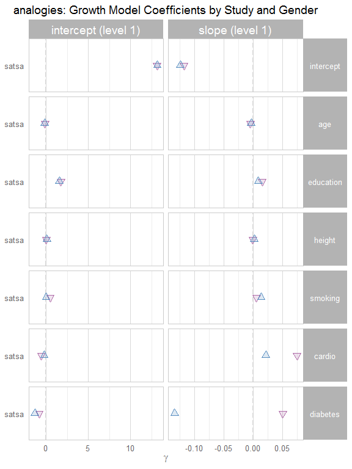

## Process Variable: block

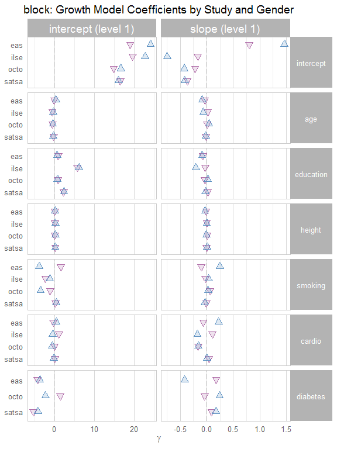

## Process Variable: bnt

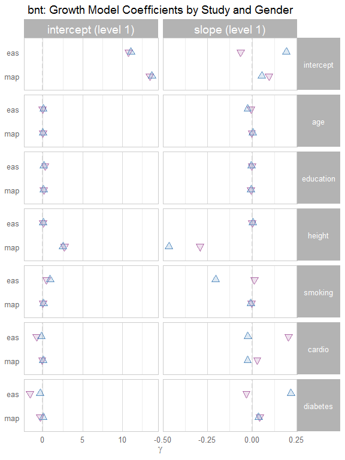

## Process Variable: bstory_de

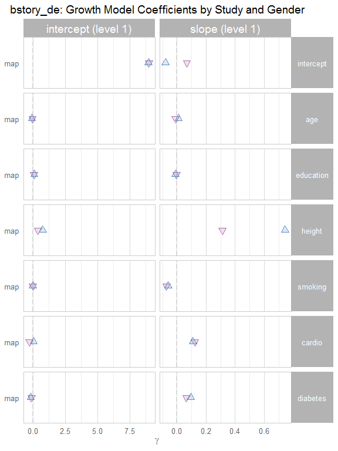

## Process Variable: bstory_im

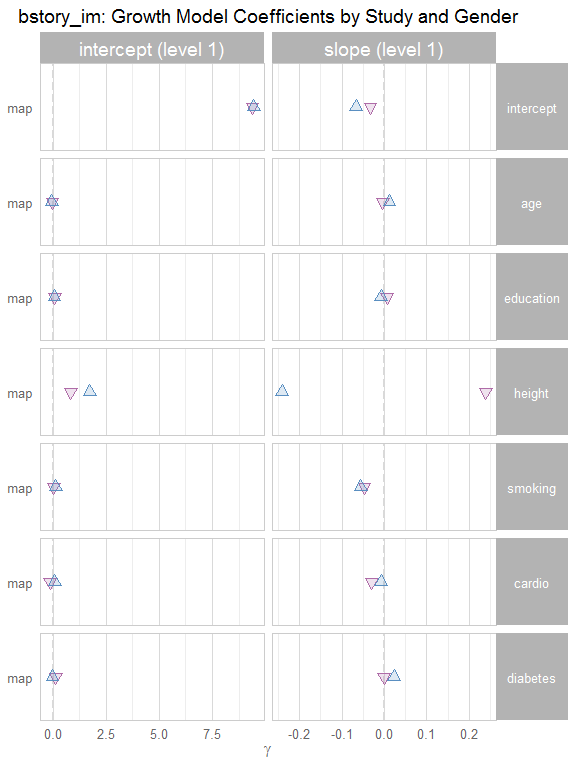

## Process Variable: categories

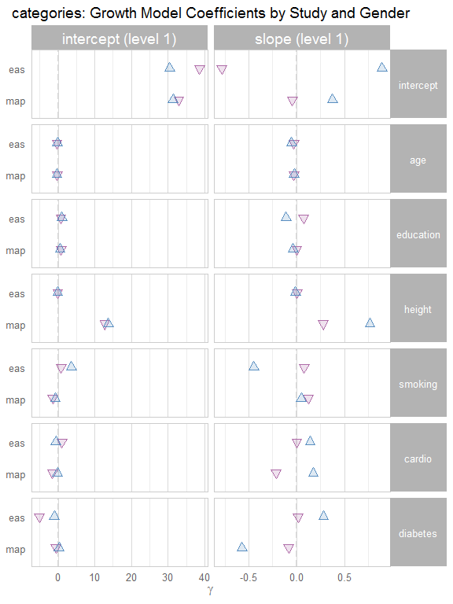

## Process Variable: digit_b

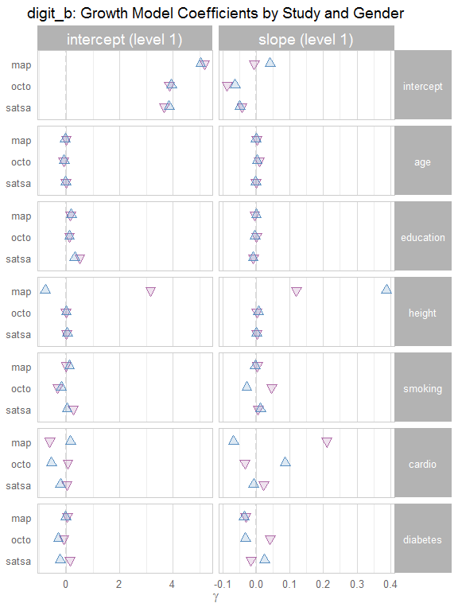

## Process Variable: digit_f

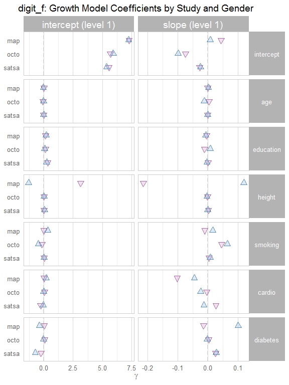

## Process Variable: digit_o

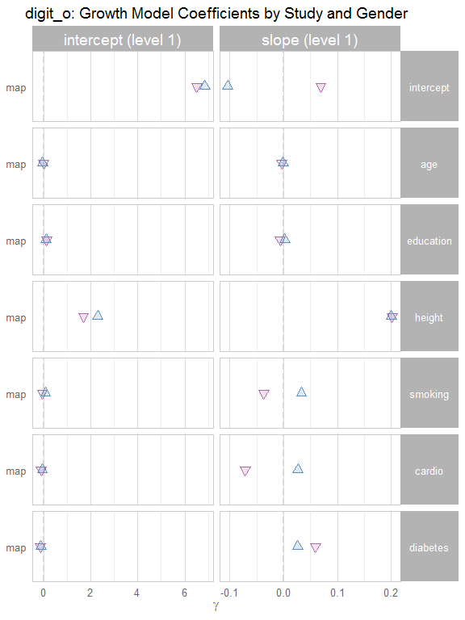

## Process Variable: digit_tot

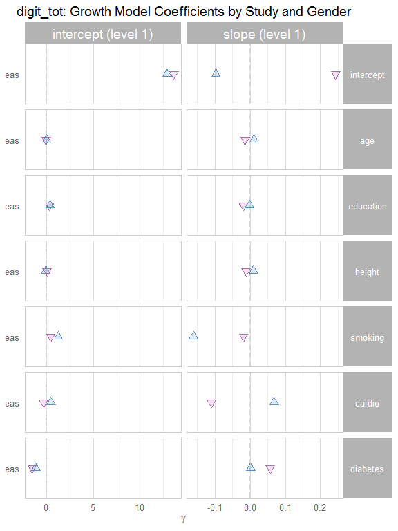

## Process Variable: fas

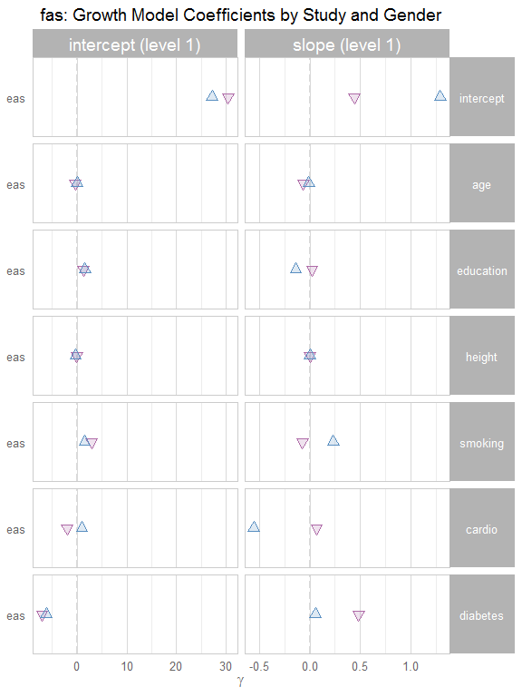

## Process Variable: fev

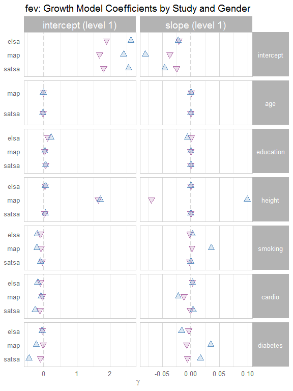

## Process Variable: fev100

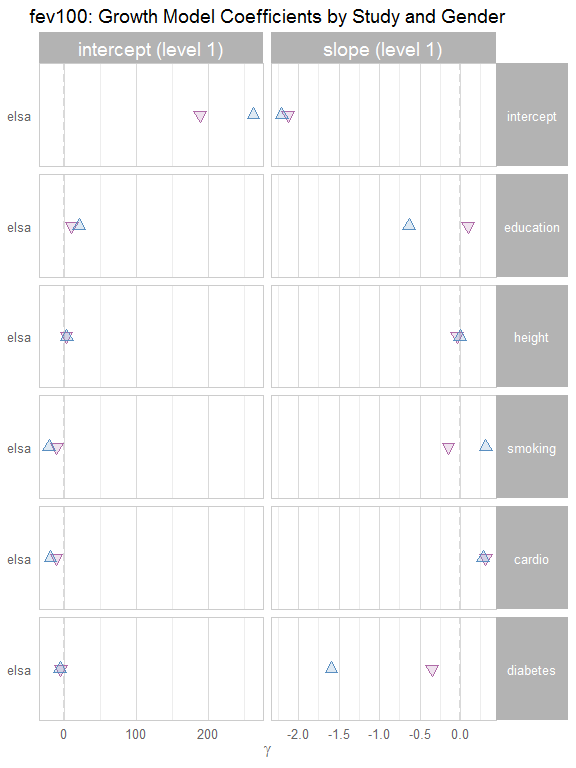

## Process Variable: fig_logic

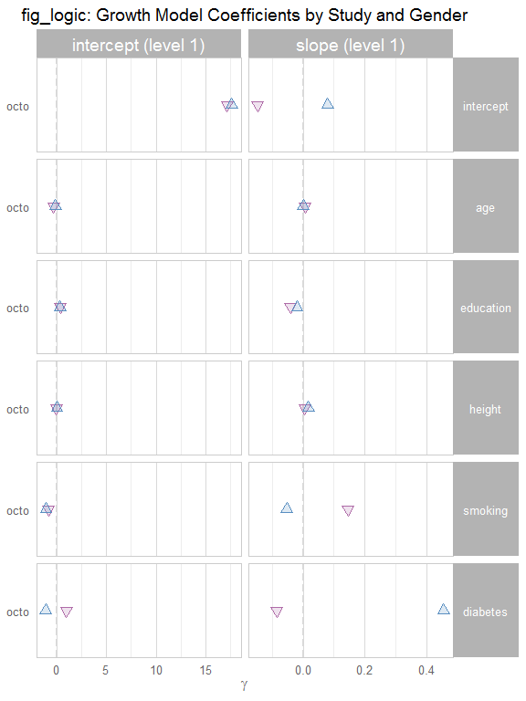

## Process Variable: fig_mem

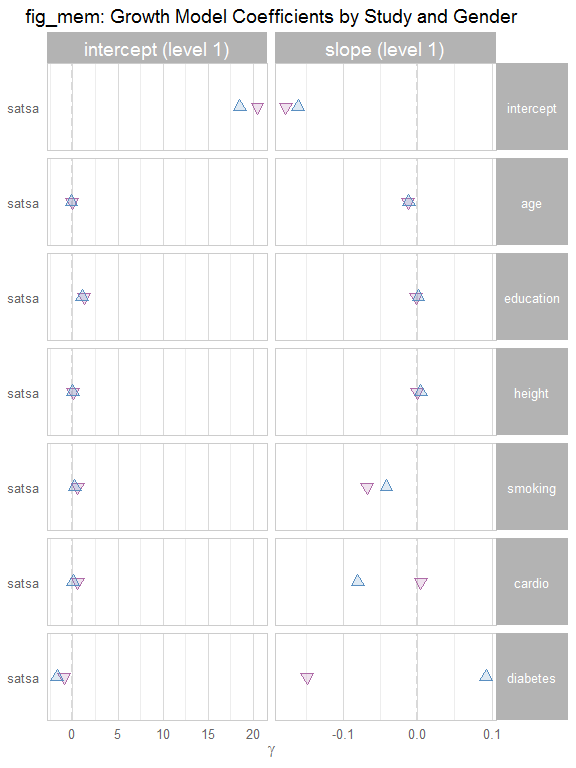

## Process Variable: fluency

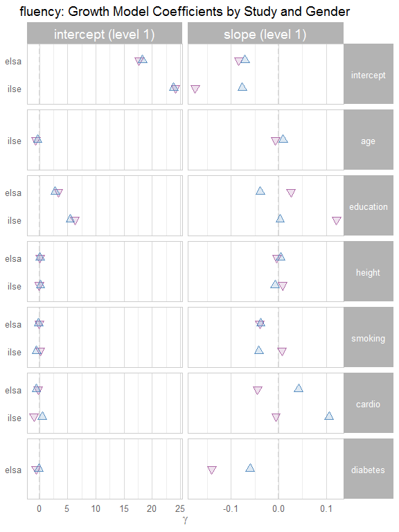

## Process Variable: gait

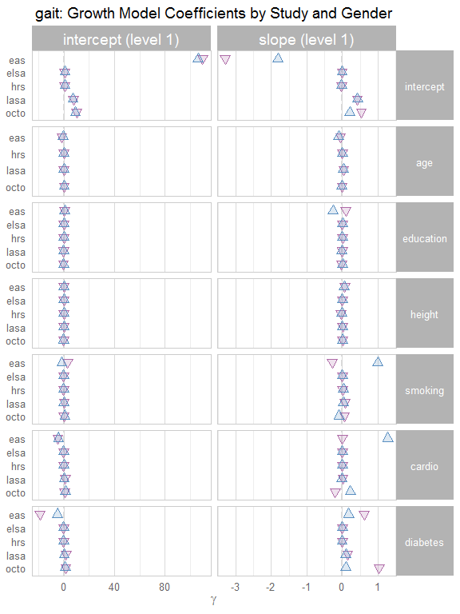

## Process Variable: grip

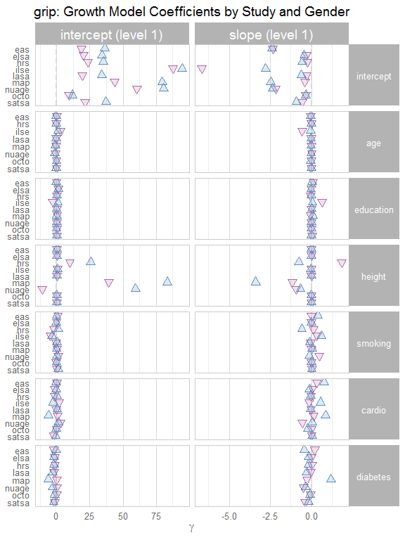

## Process Variable: ideas

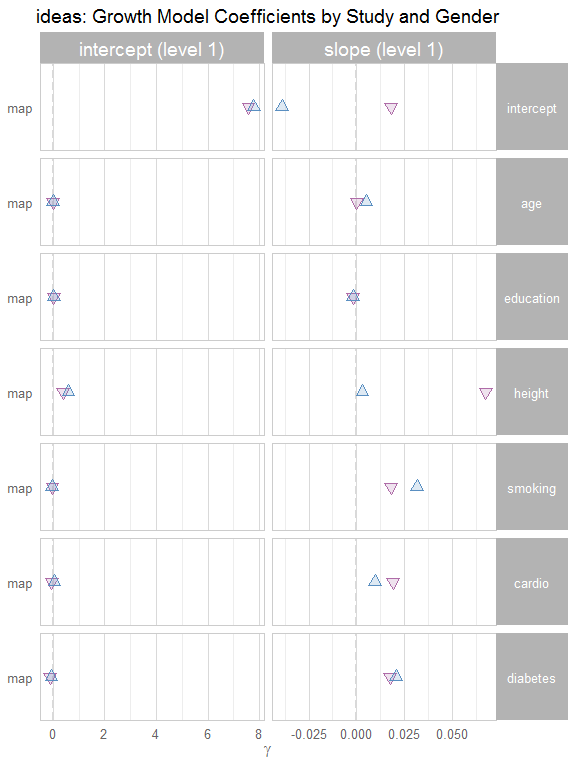

## Process Variable: information

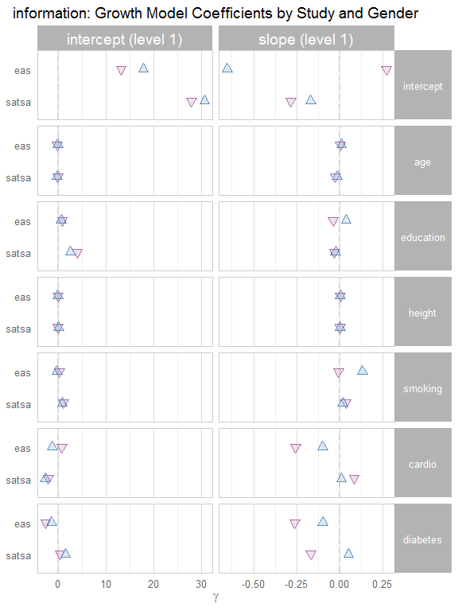

## Process Variable: letter

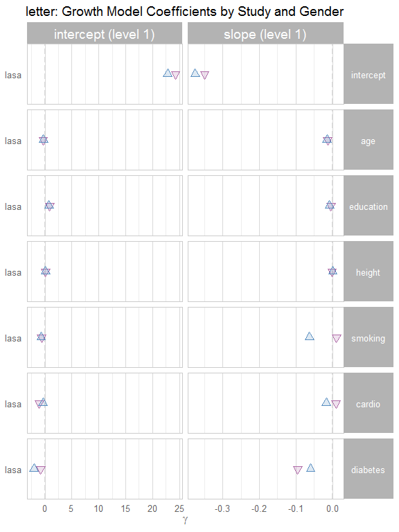

## Process Variable: line

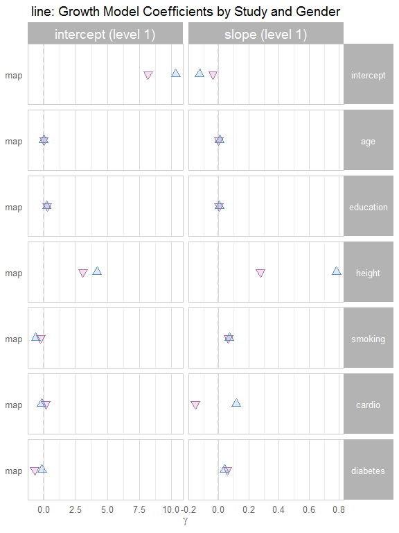

## Process Variable: logic_de

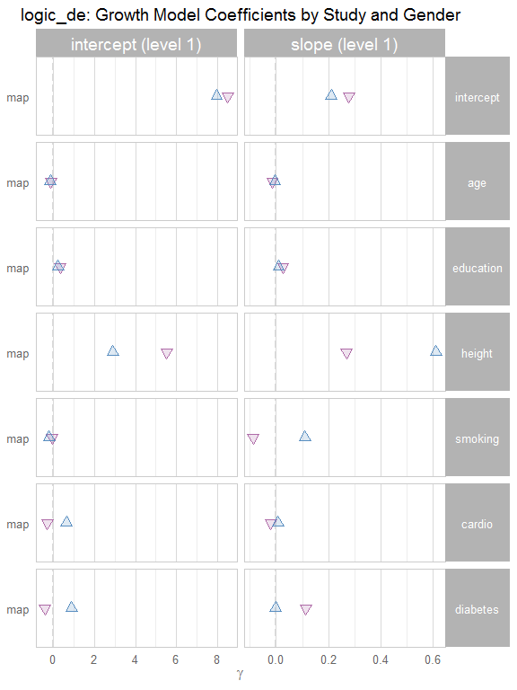

## Process Variable: logic_im

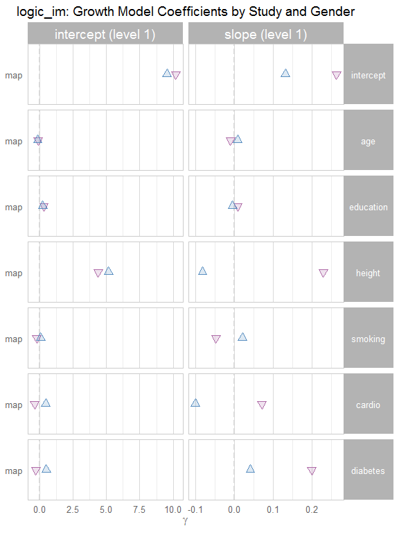

## Process Variable: logic_tot

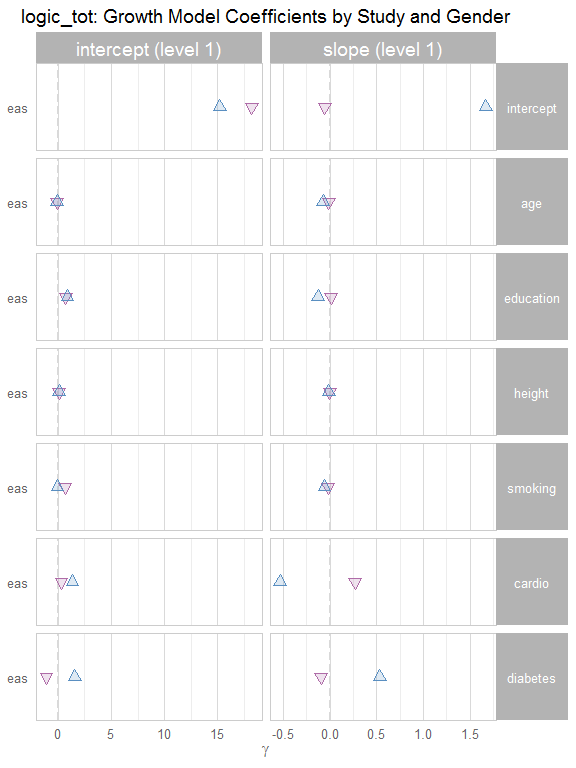

## Process Variable: matrices

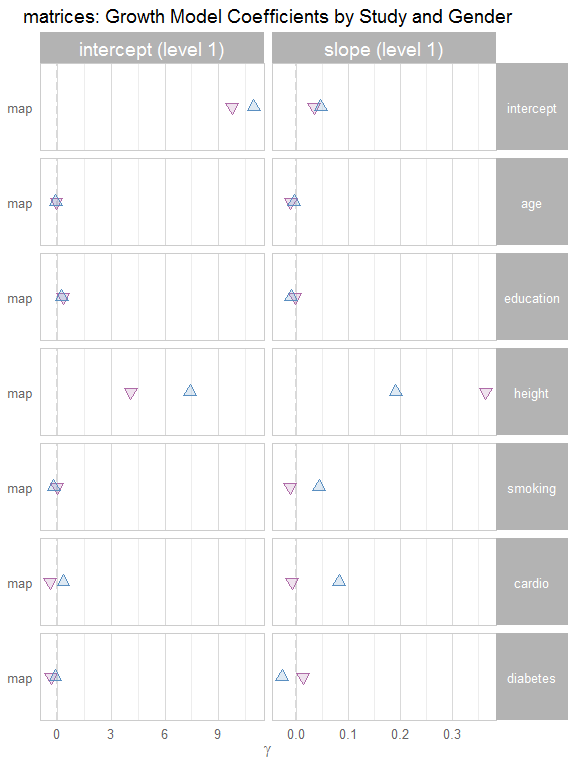

## Process Variable: mir

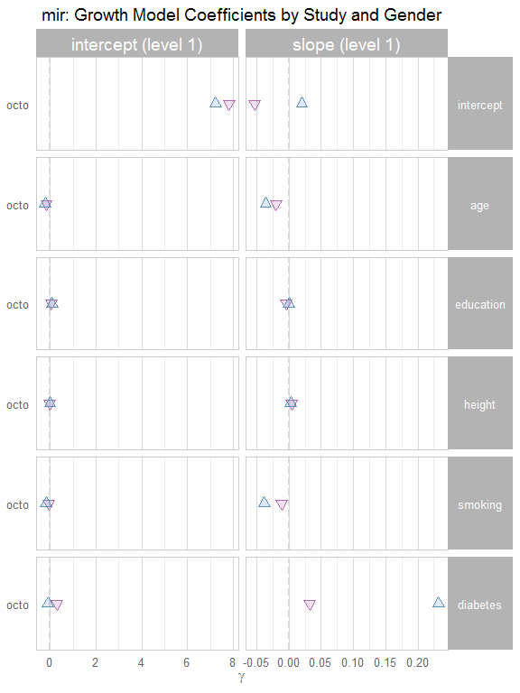

## Process Variable: mmms

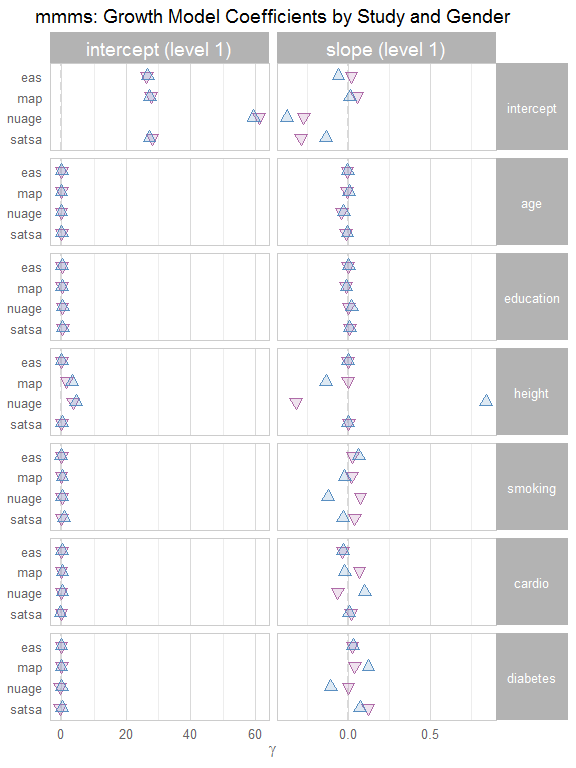

## Process Variable: nart

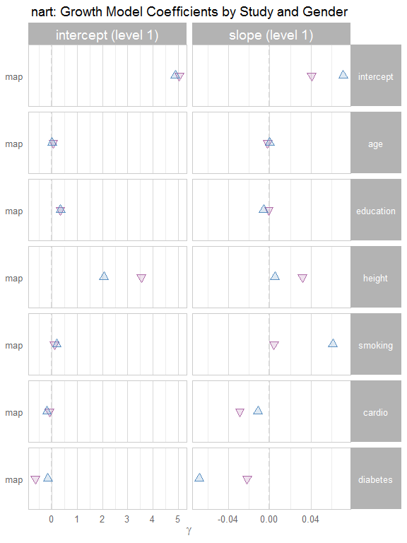

## Process Variable: num_comp

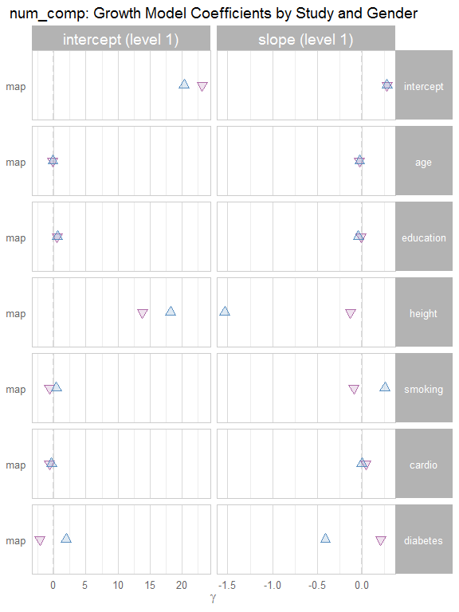

## Process Variable: pef

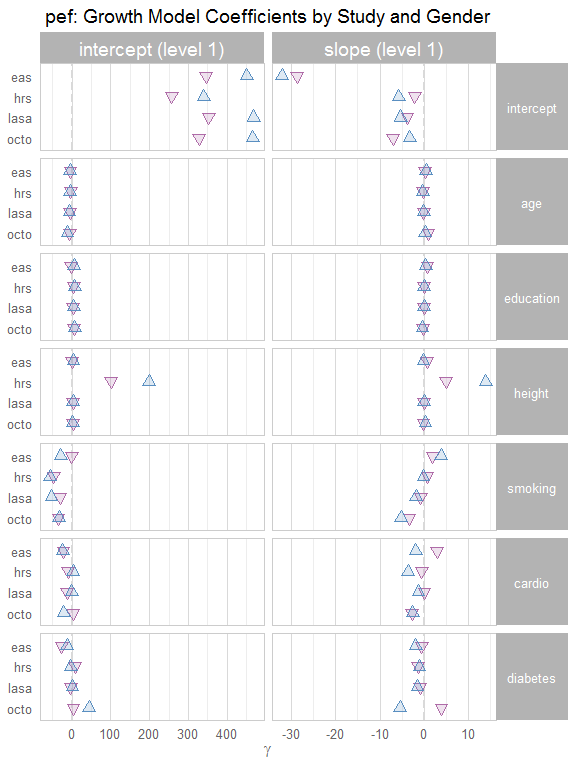